# Red Wine Exploration by Xiaoyu Chen

```
## [1] "C:/Users/youfe/Desktop/Red Wine Exploration"
```

In this exploration, I will investigate Red Wine data chosen from Data Set Options provided by Udacity. The dataset has 1599 observations with a output variable “quality”, which is scored from 3 (worst) to 8 (best), and 11 input variables: fixed.acidity (tartaric acid - g/dm^3), volatile.acidity (acetic acid - g/dm^3), citric.acid (g/dm^3), residual.sugar (g/dm^3), chlorides (sodium chlorides - g/dm^3), free.sulfur.dioxide (mg/dm^3), total.sulfur.dioxide (mg/dm^3), density (g/dm^3), pH, sulphates (potassium sulphate - g/dm^3), and alcohol (% by volume).

Most wines have quality of 5 or 6, fixed.acidity from 6.5 g/dm^3 to 9.5 g/dm^3, volatile.acidity from 0.3 g/dm^3 to 0.8 g/dm^3, citric.acid from 0 g/dm^3 to 0.5 g/dm^3, residual.sugar from 1.5 g/dm^3 to 3 g/dm^3, chlorides between 0.05 g/dm^3 and 0.1 g/dm^3, free.sulfur.dioxide between 3 mg/dm^3 to 15 mg/dm^3, total.sulfur.dioxide from 10 mg/dm^3 to 70 mg/dm^3, density from 0.994 g/dm^3 to 1 g/dm^3, Ph scale between 3 - 4, sulphates from 0.5 g/dm^3 to 0.8 g/dm^3, alcohol from 9% to 11.5%.

# Univariate Plots Section

```
## 'data.frame':    1599 obs. of  13 variables:
##  $ X                   : int  1 2 3 4 5 6 7 8 9 10 ...
##  $ fixed.acidity       : num  7.4 7.8 7.8 11.2 7.4 7.4 7.9 7.3 7.8 7.5 ...
##  $ volatile.acidity    : num  0.7 0.88 0.76 0.28 0.7 0.66 0.6 0.65 0.58 0.5 ...
##  $ citric.acid         : num  0 0 0.04 0.56 0 0 0.06 0 0.02 0.36 ...
##  $ residual.sugar      : num  1.9 2.6 2.3 1.9 1.9 1.8 1.6 1.2 2 6.1 ...
##  $ chlorides           : num  0.076 0.098 0.092 0.075 0.076 0.075 0.069 0.065 0.073 0.071 ...
##  $ free.sulfur.dioxide : num  11 25 15 17 11 13 15 15 9 17 ...
##  $ total.sulfur.dioxide: num  34 67 54 60 34 40 59 21 18 102 ...
##  $ density             : num  0.998 0.997 0.997 0.998 0.998 ...
##  $ pH                  : num  3.51 3.2 3.26 3.16 3.51 3.51 3.3 3.39 3.36 3.35 ...
##  $ sulphates           : num  0.56 0.68 0.65 0.58 0.56 0.56 0.46 0.47 0.57 0.8 ...
##  $ alcohol             : num  9.4 9.8 9.8 9.8 9.4 9.4 9.4 10 9.5 10.5 ...
##  $ quality             : int  5 5 5 6 5 5 5 7 7 5 ...
```

```
##  [1] X                    fixed.acidity        volatile.acidity
##  [4] citric.acid          residual.sugar       chlorides
##  [7] free.sulfur.dioxide  total.sulfur.dioxide density
## [10] pH                   sulphates            alcohol
## [13] quality
## <0 rows> (or 0-length row.names)
```

There is no missing values.

```
## 'data.frame':    1359 obs. of  12 variables:
##  $ fixed.acidity       : num  7.4 7.8 7.8 11.2 7.4 7.9 7.3 7.8 7.5 6.7 ...
##  $ volatile.acidity    : num  0.7 0.88 0.76 0.28 0.66 0.6 0.65 0.58 0.5 0.58 ...
##  $ citric.acid         : num  0 0 0.04 0.56 0 0.06 0 0.02 0.36 0.08 ...
##  $ residual.sugar      : num  1.9 2.6 2.3 1.9 1.8 1.6 1.2 2 6.1 1.8 ...
##  $ chlorides           : num  0.076 0.098 0.092 0.075 0.075 0.069 0.065 0.073 0.071 0.097 ...
##  $ free.sulfur.dioxide : num  11 25 15 17 13 15 15 9 17 15 ...
##  $ total.sulfur.dioxide: num  34 67 54 60 40 59 21 18 102 65 ...
##  $ density             : num  0.998 0.997 0.997 0.998 0.998 ...
##  $ pH                  : num  3.51 3.2 3.26 3.16 3.51 3.3 3.39 3.36 3.35 3.28 ...
##  $ sulphates           : num  0.56 0.68 0.65 0.58 0.56 0.46 0.47 0.57 0.8 0.54 ...
##  $ alcohol             : num  9.4 9.8 9.8 9.8 9.4 9.4 10 9.5 10.5 9.2 ...
##  $ quality             : Factor w/ 6 levels "3","4","5","6",..: 3 3 3 4 3 3 5 5 3 3 ...
```

All data types look fine right now. Let’s take a look at summary.

```
##  fixed.acidity    volatile.acidity  citric.acid     residual.sugar
##  Min.   : 4.600   Min.   :0.1200   Min.   :0.0000   Min.   : 0.900
##  1st Qu.: 7.100   1st Qu.:0.3900   1st Qu.:0.0900   1st Qu.: 1.900
##  Median : 7.900   Median :0.5200   Median :0.2600   Median : 2.200
##  Mean   : 8.311   Mean   :0.5295   Mean   :0.2723   Mean   : 2.523
##  3rd Qu.: 9.200   3rd Qu.:0.6400   3rd Qu.:0.4300   3rd Qu.: 2.600
##  Max.   :15.900   Max.   :1.5800   Max.   :1.0000   Max.   :15.500
##    chlorides       free.sulfur.dioxide total.sulfur.dioxide
##  Min.   :0.01200   Min.   : 1.00       Min.   :  6.00
##  1st Qu.:0.07000   1st Qu.: 7.00       1st Qu.: 22.00
##  Median :0.07900   Median :14.00       Median : 38.00
##  Mean   :0.08812   Mean   :15.89       Mean   : 46.83
##  3rd Qu.:0.09100   3rd Qu.:21.00       3rd Qu.: 63.00
##  Max.   :0.61100   Max.   :72.00       Max.   :289.00
##     density             pH         sulphates         alcohol      quality
##  Min.   :0.9901   Min.   :2.74   Min.   :0.3300   Min.   : 8.40   3: 10
##  1st Qu.:0.9956   1st Qu.:3.21   1st Qu.:0.5500   1st Qu.: 9.50   4: 53
##  Median :0.9967   Median :3.31   Median :0.6200   Median :10.20   5:577
##  Mean   :0.9967   Mean   :3.31   Mean   :0.6587   Mean   :10.43   6:535
##  3rd Qu.:0.9978   3rd Qu.:3.40   3rd Qu.:0.7300   3rd Qu.:11.10   7:167
##  Max.   :1.0037   Max.   :4.01   Max.   :2.0000   Max.   :14.90   8: 17
```

The quality range is from 3 (worst) to 8 (best), and most wines have quality of 5 or 6. let’s explore each variables one by one.

Next, we will examine variable distributions one by one.

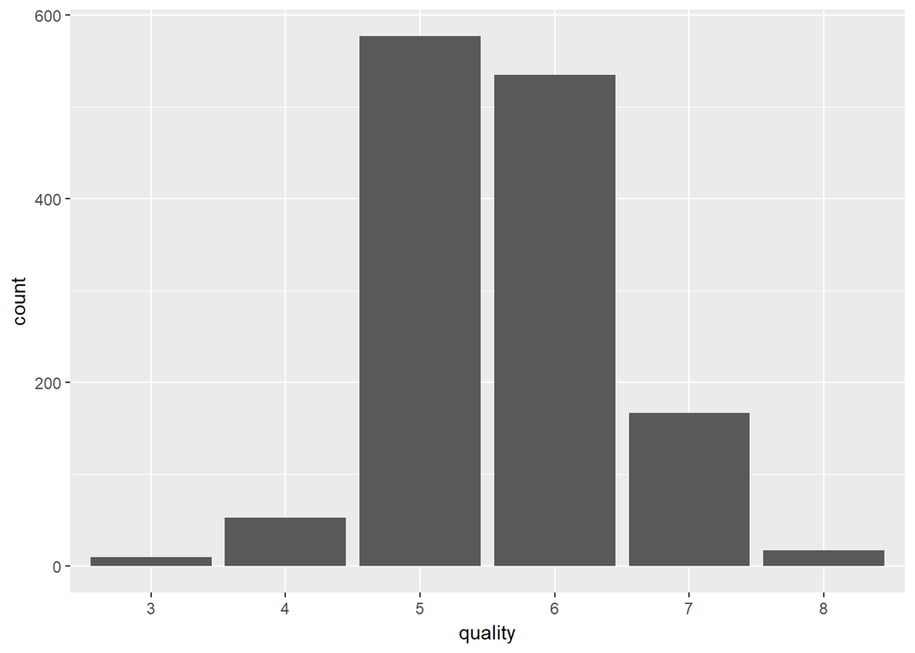

The most wines have quality of 5 or 6. The best red wines and the worst wines have least counts compared with other quality scores.

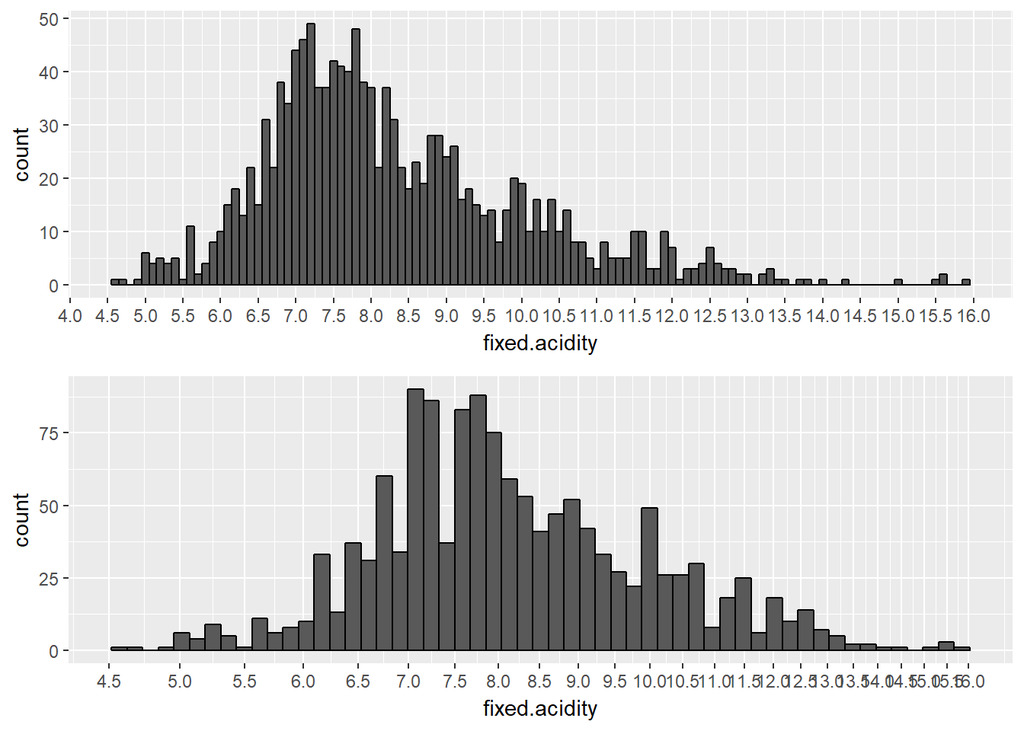

The “fixed.acidity” is transformed to log distribution because of the long right tail. The transformed distribution peaks around 7.2. Most wines have fixed.acidity from 6.5 to 9.5.

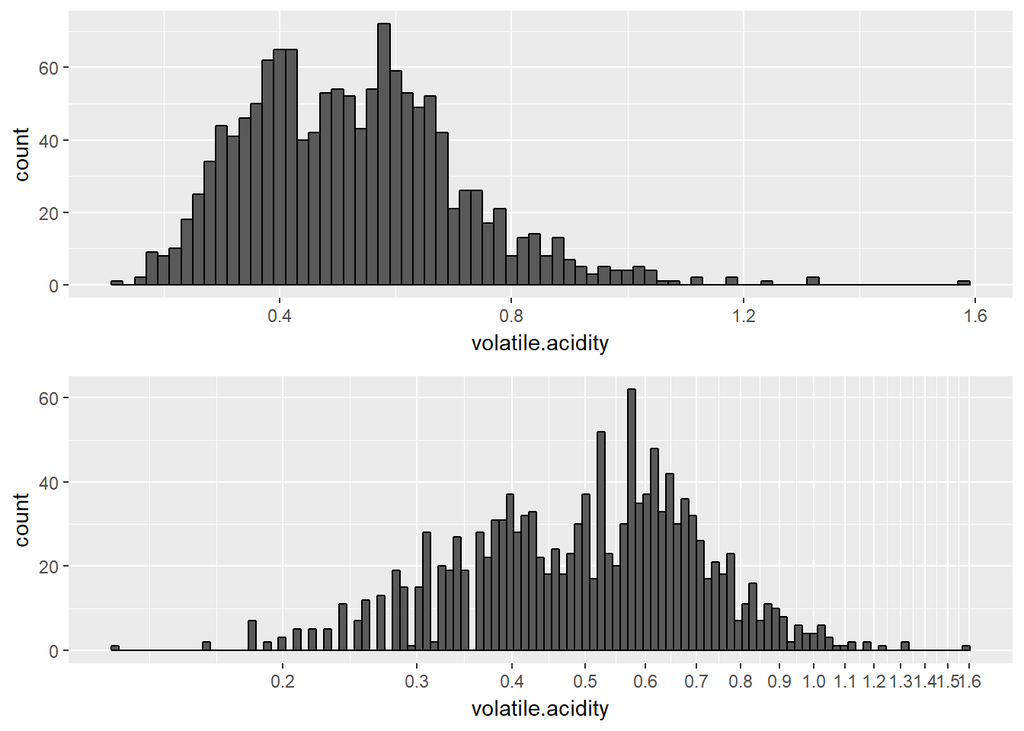

The distribution of transformed volatile.acidity peaks about 0.6. Most of volatile.acidity are from 0.3 to 0.8. Since high levels of volatile.acidity can lead to unpleasant taste, I wonder what does the quality distribution look like when given high volatile.acidity over 0.8.

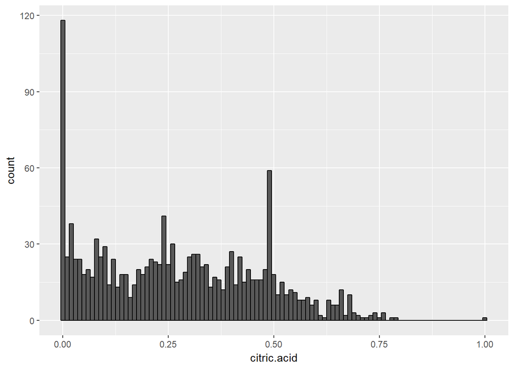

The distribution of citric.acid looks linearly decreases and peaks at 0. Since the citric.acid can add freshness and flavor to wines, I wonder what are the qualities of these wines with 0 citric.acid.

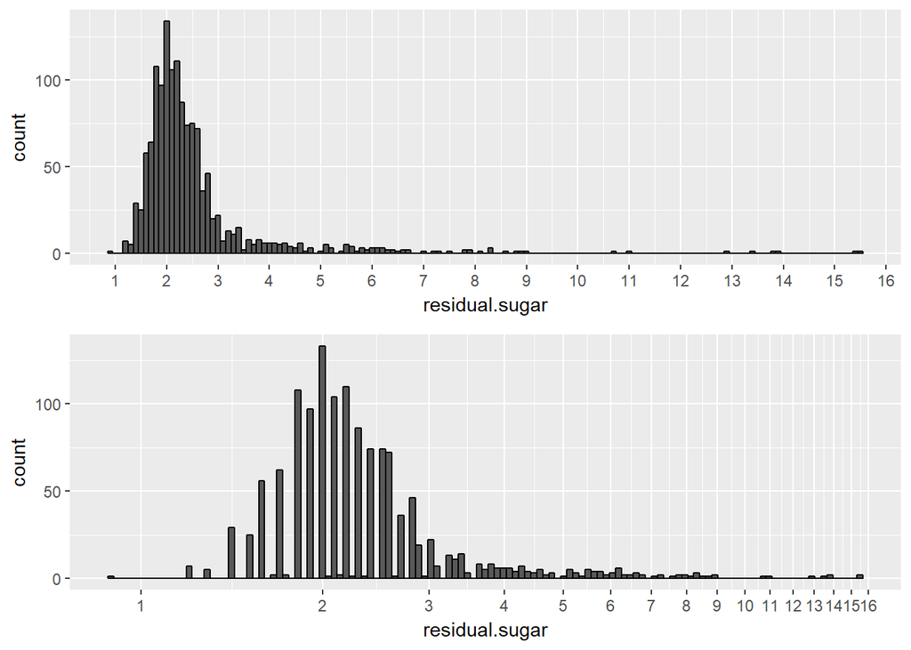

The historgram of residual.sugar is right skewed so it is log transfromed. The transformed residual.sigar peaks at 2, and most wines in the range between 1.5 and 3.

Because it’s very rare to find wines with less than 1g/liter residual.sugar, we take a look of them in the next.

```
##     fixed.acidity volatile.acidity citric.acid residual.sugar chlorides
## 867             8             0.18        0.37            0.9     0.049
##     free.sulfur.dioxide total.sulfur.dioxide density   pH sulphates
## 867                  36                  109 0.99007 2.89      0.44
##     alcohol quality
## 867    12.7       6
```

It looks all numbers are fine in this row. So we don’t consider it as outlier.

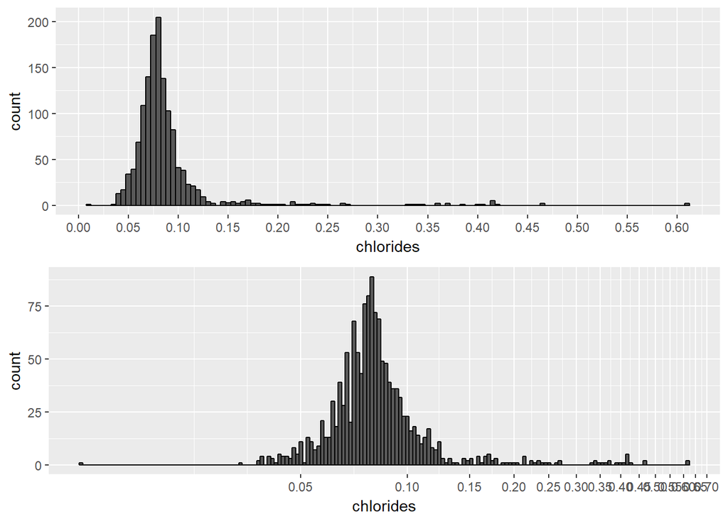

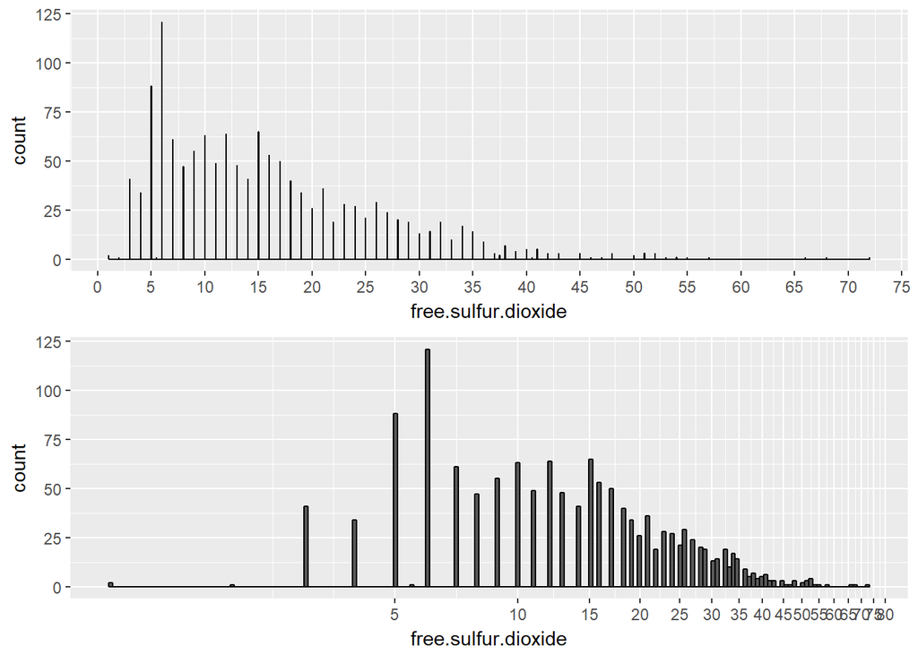

Most free.sulfur.dioxide are intergers. After transformed,free.sulfur.dioxide peaks at 6 and most wines have free.sulfur.dioxide between 3 to 15.

We know that at free SO2 concentrations over 50 ppm, SO2 becomes evident in the nose and taste of wine. So we create a new variable “Free_SO2_50” to represent whether free SO2 concentration greater than 50 ppm or not. The free SO2 concentration is calculated by using (mass of free SO2) / mass, in other words, (1L times free.sulfur.dioxide) / ( 1L times density).

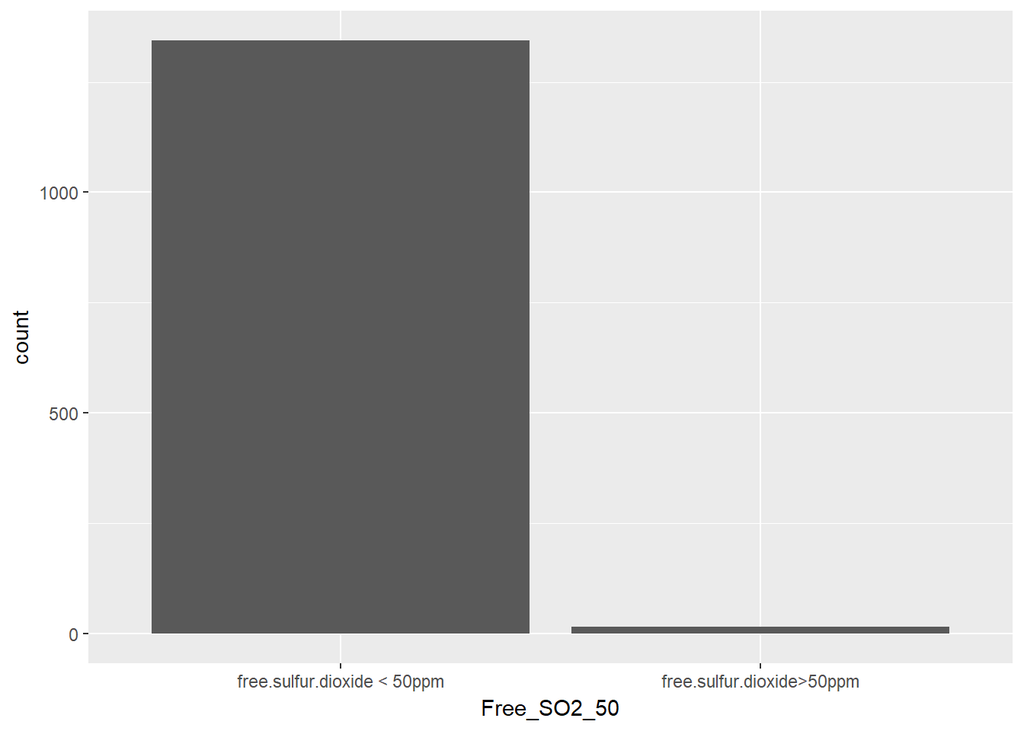

Most wines have free SO2 less than 50 ppm, but there are some over 50 ppm. I wonder what are the quality scores of wines having free SO2 over 50 ppm.

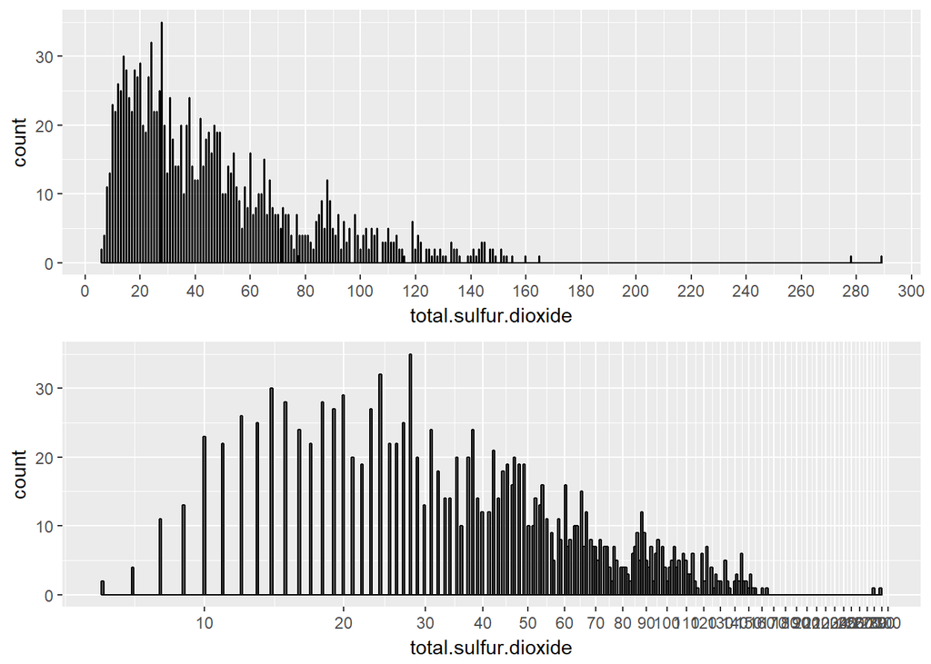

Most total.sulfur.dioxide are intergers and in the range from 10 to 70. Since total.sulfur.dioxide is sum of free and bound SO2, so we can make a new variable bound.sulfur.dioxide (mg/dm^3) to investigate its effects about red wine quality.

Let’s take a look at the distribution of the new created variable “bound.sulfur.dioxide”

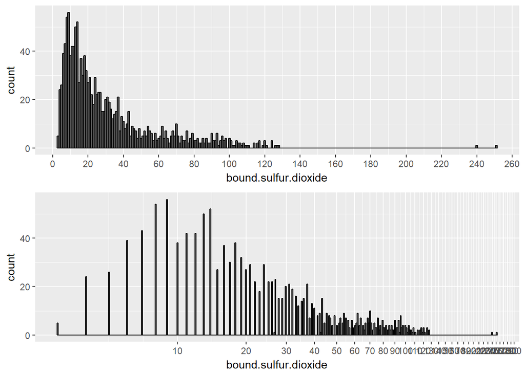

The bound.sulfur.dioxide peaks around 9. Compared with having free.sulfur.dioxide, wines contain more bound.sulfur.dioxide. I guess bound.sulfur.dioxide has very high correlation with free.sulfur.dioxide and total.sulfur.dioxide.

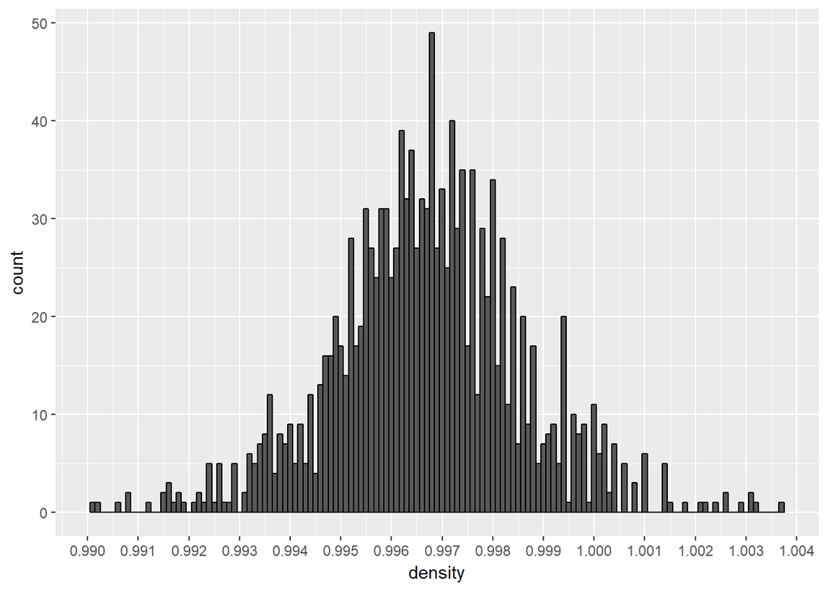

The distribution of density is normal and most of density is ranging from 0.994 to 1. The density is related to sugar and alcohol, we will check their relations in the bivariate analysis.

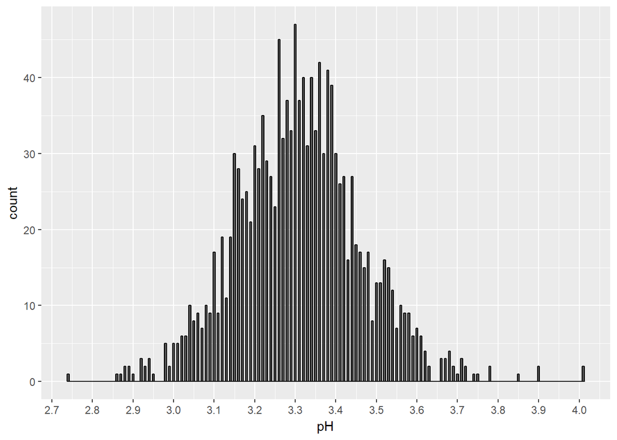

The PH distribution is normal. Most wines are between 3 - 4 on the Ph scale, sp I want to check rows with pH less than 3 in the next.

```
##      fixed.acidity volatile.acidity citric.acid residual.sugar chlorides
## 81             8.6            0.490        0.28            1.9     0.110
## 86             8.6            0.490        0.29            2.0     0.110
## 136            9.2            0.520        1.00            3.4     0.610
## 319           12.5            0.460        0.63            2.0     0.071
## 384           12.6            0.310        0.72            2.2     0.072
## 386           15.6            0.685        0.76            3.7     0.100
## 406           11.5            0.315        0.54            2.1     0.084
## 474           14.3            0.310        0.74            1.8     0.075
## 484           15.5            0.645        0.49            4.2     0.095
## 486           15.6            0.645        0.49            4.2     0.095
## 506           12.0            0.280        0.49            1.9     0.074
## 532           13.2            0.380        0.55            2.7     0.081
## 535            9.2            0.755        0.18            2.2     0.148
## 564           10.7            0.430        0.39            2.2     0.106
```

[output cut: 60 more lines]

The all rows have very high values of sulfur.dioxide or citric.acid or fixed.acidity. It looks that pH is related to sulfur.dioxide and acidity.

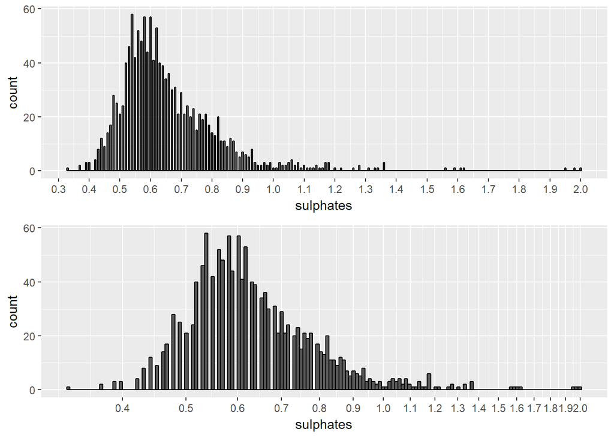

Most wines have sulphates between 0.5 to 0.8. I guess sulphates have close correlation with free.sulfur.dioxide.

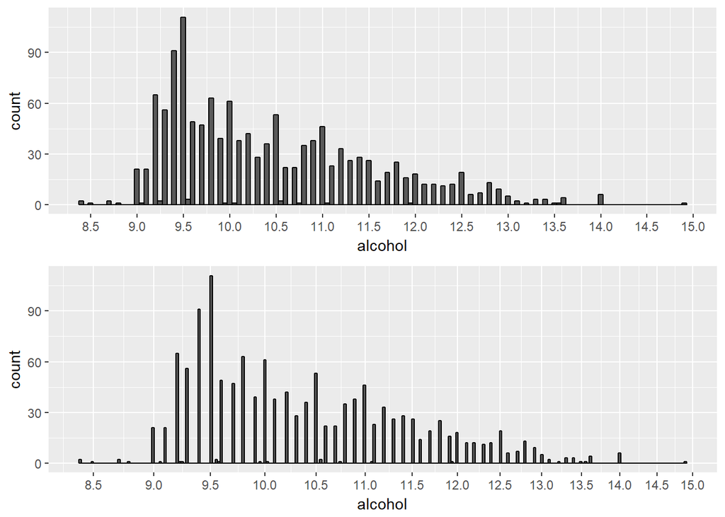

Alcohol peaks around 9.5 and the count of wines are decreasing as alcohol increasing more than 9.5. Most wines have alcohol ranging from 9% to 11.5%.

After displaying every single variable, we found that all attributes in red wines could be concluded in:acidity, sulfur dioxide, sugar, salt, and alcohol. I guess that density has close clorrelation with sugar, salt and alcohol. The pH value has close correlation with acidity and probably the concentration of sulfur dioxide.

# Univariate Analysis

### What is the structure of your dataset?

There are 1359 unique wines in the dataset with 11 attributes (fixed acidity, volatile acidity, citric acid, residual sugar, chlorides, free sulfur dioxide, total sulfur dioxide, density, pH, sulphates, and alcohol). All of attributes are numeric data.

### What is/are the main feature(s) of interest in your dataset?

The main features in the dataset are alcohol and quality.

### What other features in the dataset do you think will help support your investigation into your feature(s) of interest?

I guess fixed acidity, volatile acidity, citric acid, residual sugar, chlorides, free sulfur dioxide, total sulfur dioxide, and sulphates will help support my investigation.

### Did you create any new variables from existing variables in the dataset?

I create two new variables in total.

The second is “bound.sulfur.dioxide” (mg/dm^3), which is created by using total.sulfur.dioxide minus free.sulfur.dioxide.

### Of the features you investigated, were there any unusual distributions? Did you perform any operations on the data to tidy, adjust, or change the form of the data? If so, why did you do this?

I remove duplicated rows before display structure of dataset. Because I think same wines could not help us more to investigate the dataset.

I use log10 to transform almost all features beacuase of right skewed.

It’s very rare to find wines with less than 1g/liter residual.sugar, but we do have a wine with 0.9. I list the row out to see if it is a outlier. Since other variables look fine, so I keep it.

# Bivariate Plots Section

```
##
## Two-Step Estimates
##
## Correlations/Type of Correlation:
##                      fixed.acidity volatile.acidity citric.acid
## fixed.acidity                    1          Pearson     Pearson
## volatile.acidity           -0.2551                1     Pearson
## citric.acid                 0.6674          -0.5512           1
## residual.sugar               0.111        -0.002449      0.1439
## chlorides                  0.08589          0.05515      0.2102
## free.sulfur.dioxide        -0.1406         -0.02094      -0.048
## total.sulfur.dioxide       -0.1038           0.0717     0.04736
## density                     0.6702          0.02394       0.358
## pH                         -0.6867           0.2471     -0.5503
## sulphates                   0.1903          -0.2569      0.3261
## alcohol                    -0.0616          -0.1978      0.1051
## quality                     0.1257          -0.4251      0.2426
## Free_SO2_50               -0.09827         -0.07687     -0.1057
## bound.sulfur.dioxide      -0.07251          0.09486     0.07561
##                      residual.sugar chlorides free.sulfur.dioxide
## fixed.acidity               Pearson   Pearson             Pearson
## volatile.acidity            Pearson   Pearson             Pearson
## citric.acid                 Pearson   Pearson             Pearson
## residual.sugar                    1   Pearson             Pearson
## chlorides                   0.02666         1             Pearson
## free.sulfur.dioxide          0.1605 0.0007486                   1
## total.sulfur.dioxide          0.201   0.04577              0.6672
## density                      0.3245    0.1936            -0.01807
## pH                         -0.08314   -0.2709             0.05663
## sulphates                  -0.01184    0.3946             0.05413
## alcohol                     0.06328   -0.2238            -0.08012
## quality                     0.01223   -0.1407            -0.05223
## Free_SO2_50                  0.2418    0.1275                <NA>
## bound.sulfur.dioxide         0.1829    0.0552              0.4298
##                      total.sulfur.dioxide density       pH sulphates
## fixed.acidity                     Pearson Pearson  Pearson   Pearson
## volatile.acidity                  Pearson Pearson  Pearson   Pearson
## citric.acid                       Pearson Pearson  Pearson   Pearson
## residual.sugar                    Pearson Pearson  Pearson   Pearson
## chlorides                         Pearson Pearson  Pearson   Pearson
```

[output cut: 135 more lines]

```
##                        alcohol   quality Free_SO2_50
## fixed.acidity
## volatile.acidity
## citric.acid
## residual.sugar
## chlorides
## free.sulfur.dioxide
## total.sulfur.dioxide
## density
## pH
## sulphates
## alcohol
## quality              8.451e-32
## Free_SO2_50          7.154e-16    0.6777
## bound.sulfur.dioxide 8.091e-53 4.991e-40   6.531e-30
```

Residual.sugar only moderately correlates with density, and chlorides only correlates with sulphates. There is no other obvious correlations in both residual.sugar and chlorides.

One interestin finding is that, all sulfur dioxide (free, bound and total) only highly correlated with each other, and have no meaningful corelations with other variables, including quality. Both bound and free sulfur dioxide have large correlations with total sulfur dioxide, which makes sense. Bound sulfur dioxide and free are moderately correlated.

Another interesting finding is that although “sulphates” can contribute to sulfur dioxide gas levels, the correlation between them is much weaker than I expected.

Because of the previous conclusions, let’s subset data with variables excluding “residual.sugar”, “chlorides”, “free.sulfur.dioxide”, “total.sulfur.dioxide”, “bound.sulfur.dioxide” and “Free_SO2_50”.

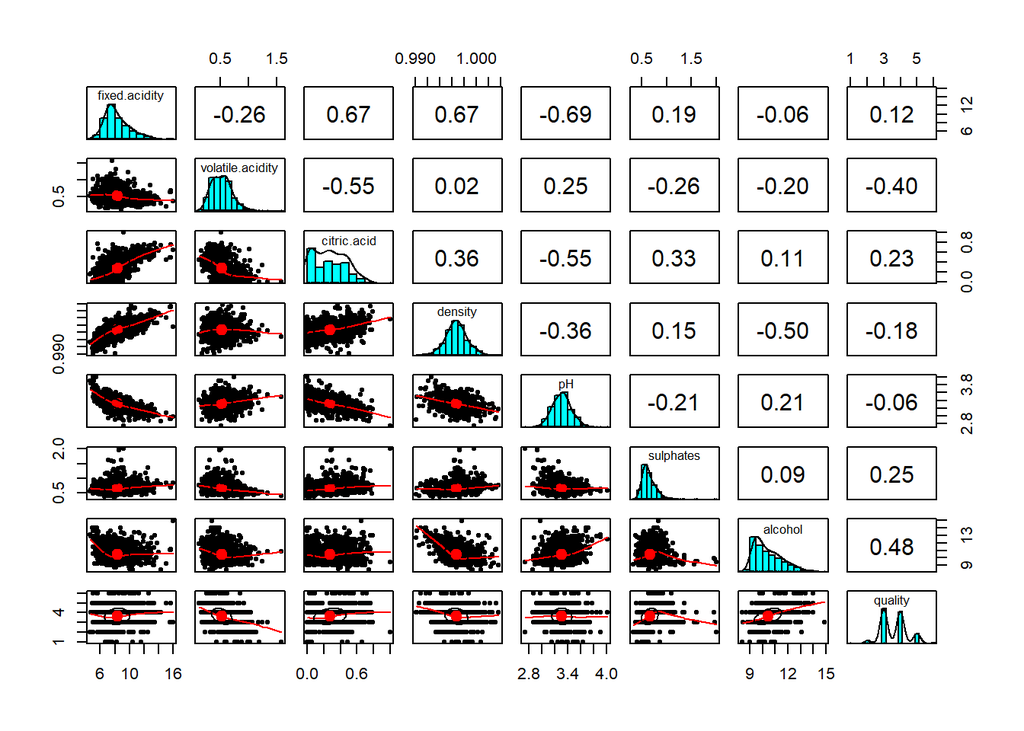

Quality has moderate correlations with alcohol and Volatile.acidity, and slight correlation with Sulphates and citric.acidity.

One unexpected finding is that density is highly correlated with fixed.acidity. At the same time, density has no obvious correlation with volatile.acidity and meaningful correlation with citric.acid.

We will look closer at plots about quality and some other variables, including alcohol, volatile.acidity, sulphates, citric acidity, density, bound.sulfur.dioxide and Free_SO2_50.

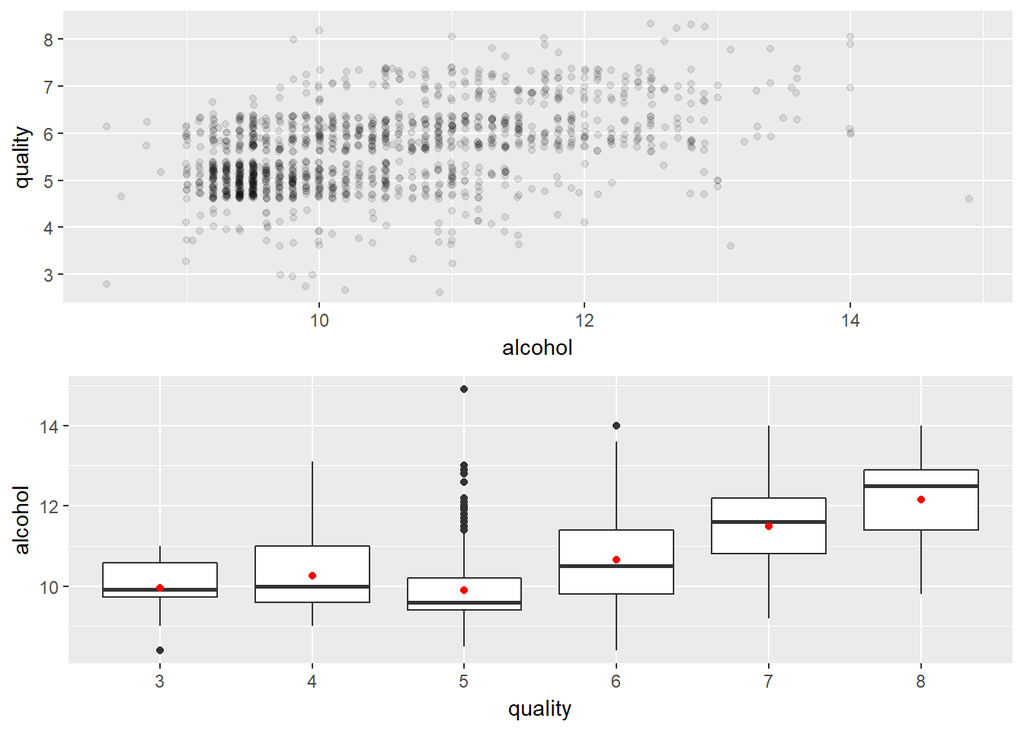

```
## df$quality: 3
##    Min. 1st Qu.  Median    Mean 3rd Qu.    Max.
##   8.400   9.725   9.925   9.955  10.575  11.000
## --------------------------------------------------------
## df$quality: 4
##    Min. 1st Qu.  Median    Mean 3rd Qu.    Max.
##    9.00    9.60   10.00   10.27   11.00   13.10
## --------------------------------------------------------
## df$quality: 5
##    Min. 1st Qu.  Median    Mean 3rd Qu.    Max.
##   8.500   9.400   9.600   9.889  10.200  14.900
## --------------------------------------------------------
## df$quality: 6
##    Min. 1st Qu.  Median    Mean 3rd Qu.    Max.
##    8.40    9.80   10.50   10.66   11.40   14.00
## --------------------------------------------------------
## df$quality: 7
##    Min. 1st Qu.  Median    Mean 3rd Qu.    Max.
##    9.20   10.80   11.60   11.49   12.20   14.00
## --------------------------------------------------------
## df$quality: 8
##    Min. 1st Qu.  Median    Mean 3rd Qu.    Max.
##    9.80   11.40   12.50   12.16   12.90   14.00
```

As alcohol increases, the quality gets more chance at higher levels. Quality of 5 looks have lowest median of alcohol, and it also has least variance in the middle 50%.

We also notice that many wines have same levels of alcohol at different quality.

```
##
## Call:
## lm(formula = quality ~ alcohol, data = df)
##
## Residuals:
##     Min      1Q  Median      3Q     Max
## -2.8308 -0.3921 -0.1727  0.5348  2.6079
##
## Coefficients:
##             Estimate Std. Error t value Pr(>|t|)
## (Intercept)  1.80923    0.19007   9.519   <2e-16 ***
## alcohol      0.36560    0.01812  20.174   <2e-16 ***
## ---
## Signif. codes:  0 '***' 0.001 '**' 0.01 '*' 0.05 '.' 0.1 ' ' 1
##
## Residual standard error: 0.7226 on 1357 degrees of freedom
## Multiple R-squared:  0.2307, Adjusted R-squared:  0.2302
## F-statistic:   407 on 1 and 1357 DF,  p-value: < 2.2e-16
```

Based on the R^2 value, alcohol can explain 23% of the variance in quality.

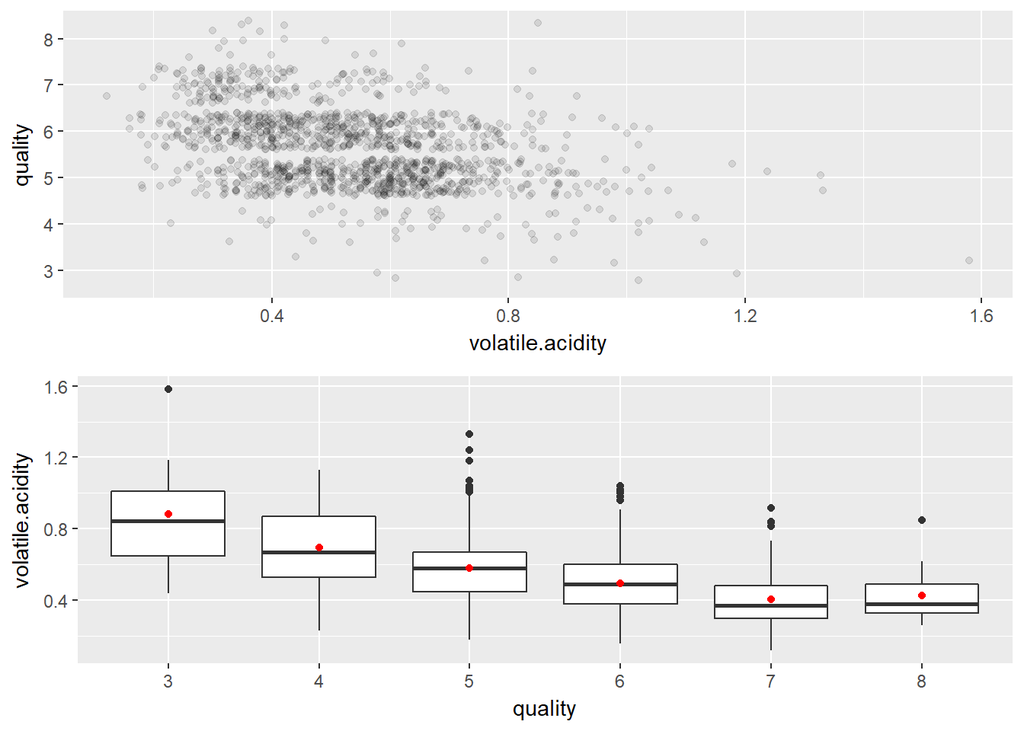

```
## df$quality: 3
##    Min. 1st Qu.  Median    Mean 3rd Qu.    Max.
##  0.4400  0.6475  0.8450  0.8845  1.0100  1.5800
## --------------------------------------------------------
## df$quality: 4
##    Min. 1st Qu.  Median    Mean 3rd Qu.    Max.
##   0.230   0.530   0.670   0.694   0.870   1.130
## --------------------------------------------------------
## df$quality: 5
##    Min. 1st Qu.  Median    Mean 3rd Qu.    Max.
##  0.1800  0.4500  0.5800  0.5786  0.6700  1.3300
## --------------------------------------------------------
## df$quality: 6
##    Min. 1st Qu.  Median    Mean 3rd Qu.    Max.
##  0.1600  0.3800  0.4900  0.4961  0.6000  1.0400
## --------------------------------------------------------
## df$quality: 7
##    Min. 1st Qu.  Median    Mean 3rd Qu.    Max.
##  0.1200  0.3000  0.3700  0.4037  0.4800  0.9150
## --------------------------------------------------------
## df$quality: 8
##    Min. 1st Qu.  Median    Mean 3rd Qu.    Max.
##  0.2600  0.3300  0.3800  0.4276  0.4900  0.8500
```

```
##
## Call:
## lm(formula = quality ~ volatile.acidity, data = df)
##
## Residuals:
##     Min      1Q  Median      3Q     Max
## -2.7824 -0.5334 -0.0088  0.4666  2.9467
##
## Coefficients:
##                  Estimate Std. Error t value Pr(>|t|)
## (Intercept)       6.56484    0.06286  104.44   <2e-16 ***
## volatile.acidity -1.77833    0.11220  -15.85   <2e-16 ***
## ---
## Signif. codes:  0 '***' 0.001 '**' 0.01 '*' 0.05 '.' 0.1 ' ' 1
##
## Residual standard error: 0.7568 on 1357 degrees of freedom
## Multiple R-squared:  0.1562, Adjusted R-squared:  0.1556
## F-statistic: 251.2 on 1 and 1357 DF,  p-value: < 2.2e-16
```

It looks that volatile.acidity has a little worse explaination power than alcohol on quality. There is 16% of the variance in quality can be explained by volatile.acidity.

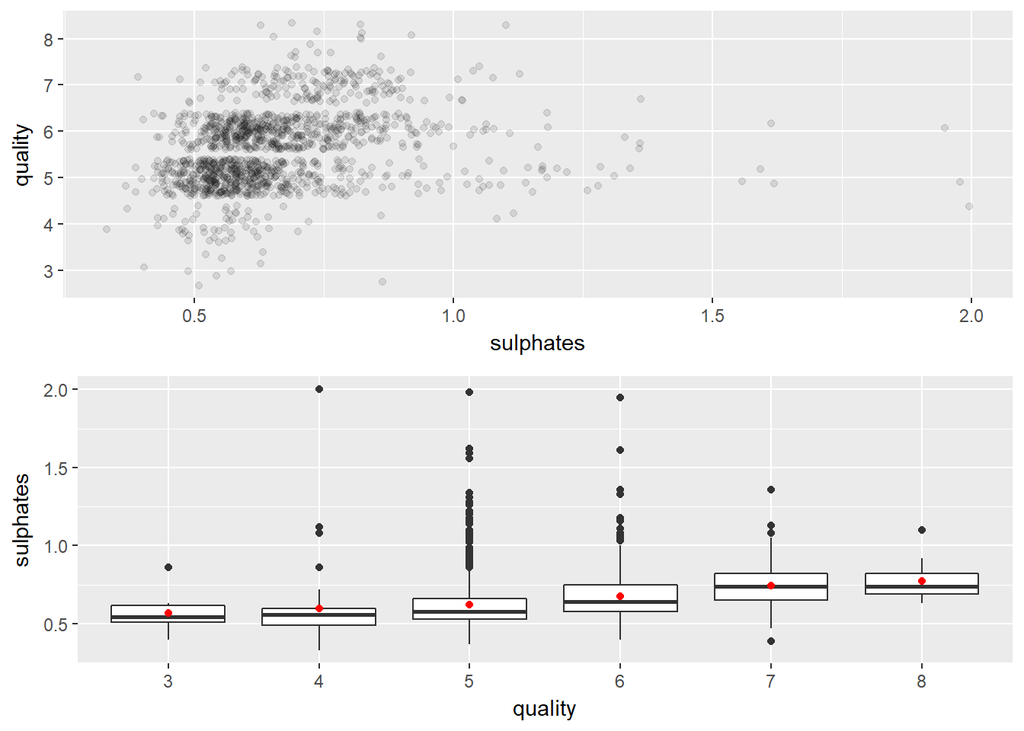

```
## df$quality: 3
##    Min. 1st Qu.  Median    Mean 3rd Qu.    Max.
##  0.4000  0.5125  0.5450  0.5700  0.6150  0.8600
## --------------------------------------------------------
## df$quality: 4
##    Min. 1st Qu.  Median    Mean 3rd Qu.    Max.
##  0.3300  0.4900  0.5600  0.5964  0.6000  2.0000
## --------------------------------------------------------
## df$quality: 5
##    Min. 1st Qu.  Median    Mean 3rd Qu.    Max.
##  0.3700  0.5300  0.5800  0.6236  0.6600  1.9800
## --------------------------------------------------------
## df$quality: 6
##    Min. 1st Qu.  Median    Mean 3rd Qu.    Max.
##  0.4000  0.5800  0.6400  0.6745  0.7500  1.9500
## --------------------------------------------------------
## df$quality: 7
##    Min. 1st Qu.  Median    Mean 3rd Qu.    Max.
##  0.3900  0.6500  0.7400  0.7426  0.8200  1.3600
## --------------------------------------------------------
## df$quality: 8
##    Min. 1st Qu.  Median    Mean 3rd Qu.    Max.
##  0.6300  0.6900  0.7400  0.7747  0.8200  1.1000
```

As sulphates increase, quality tends to be higher. Quality of 7 and 8 have same median of sulphates, but 8 has less variance than 7.

Many wines having same levels of sulphates are scored differently.

```
##
## Call:
## lm(formula = quality ~ sulphates, data = df)
##
## Residuals:
##     Min      1Q  Median      3Q     Max
## -3.2339 -0.5408  0.0990  0.4592  2.4112
##
## Coefficients:
##             Estimate Std. Error t value Pr(>|t|)
## (Intercept)  4.83229    0.08633  55.973   <2e-16 ***
## sulphates    1.20079    0.12688   9.464   <2e-16 ***
## ---
## Signif. codes:  0 '***' 0.001 '**' 0.01 '*' 0.05 '.' 0.1 ' ' 1
##
## Residual standard error: 0.798 on 1357 degrees of freedom
## Multiple R-squared:  0.06192,    Adjusted R-squared:  0.06123
## F-statistic: 89.57 on 1 and 1357 DF,  p-value: < 2.2e-16
```

There is 6% of the variance in quality can be explained by sulphates.

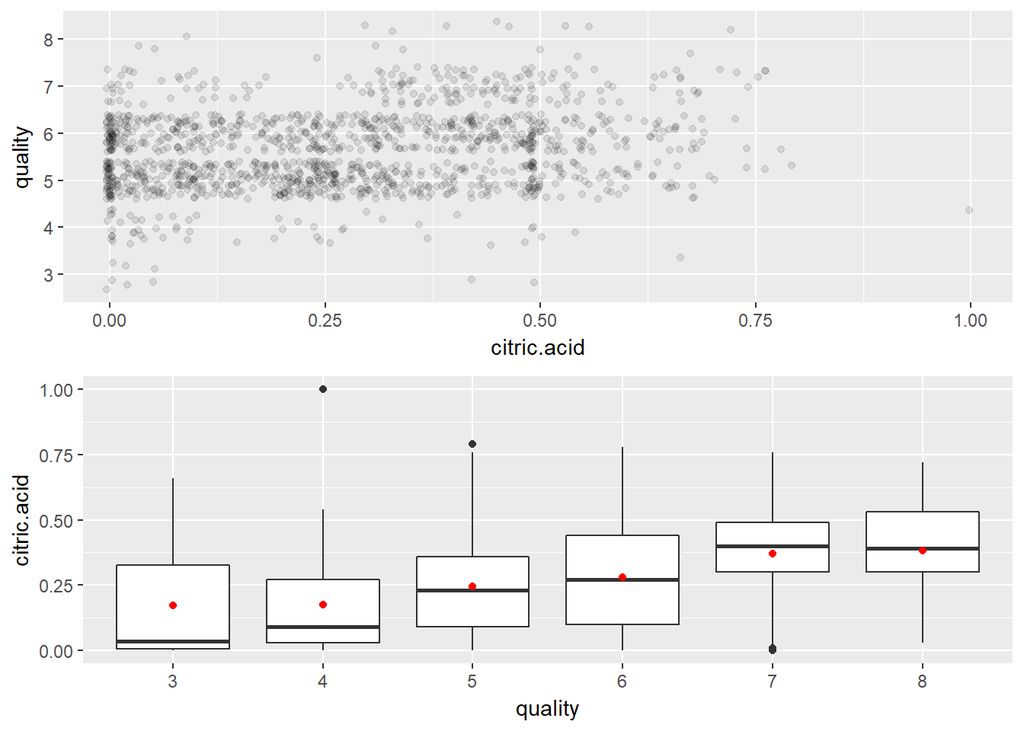

```
## df$quality: 3
##    Min. 1st Qu.  Median    Mean 3rd Qu.    Max.
##  0.0000  0.0050  0.0350  0.1710  0.3275  0.6600
## --------------------------------------------------------
## df$quality: 4
##    Min. 1st Qu.  Median    Mean 3rd Qu.    Max.
##  0.0000  0.0300  0.0900  0.1742  0.2700  1.0000
## --------------------------------------------------------
## df$quality: 5
##    Min. 1st Qu.  Median    Mean 3rd Qu.    Max.
##  0.0000  0.0900  0.2300  0.2445  0.3600  0.7900
## --------------------------------------------------------
## df$quality: 6
##    Min. 1st Qu.  Median    Mean 3rd Qu.    Max.
##  0.0000  0.1000  0.2700  0.2794  0.4400  0.7800
## --------------------------------------------------------
## df$quality: 7
##    Min. 1st Qu.  Median    Mean 3rd Qu.    Max.
##  0.0000  0.3000  0.4000  0.3719  0.4900  0.7600
## --------------------------------------------------------
## df$quality: 8
##    Min. 1st Qu.  Median    Mean 3rd Qu.    Max.
##  0.0300  0.3000  0.3900  0.3829  0.5300  0.7200
```

Quality and citric.acid have slight correlation from scatter plot. The means and medians of citric.acid are having upward trends as quality increases.

We also found that all wines with 0 citric.acid could be any scores except 8.

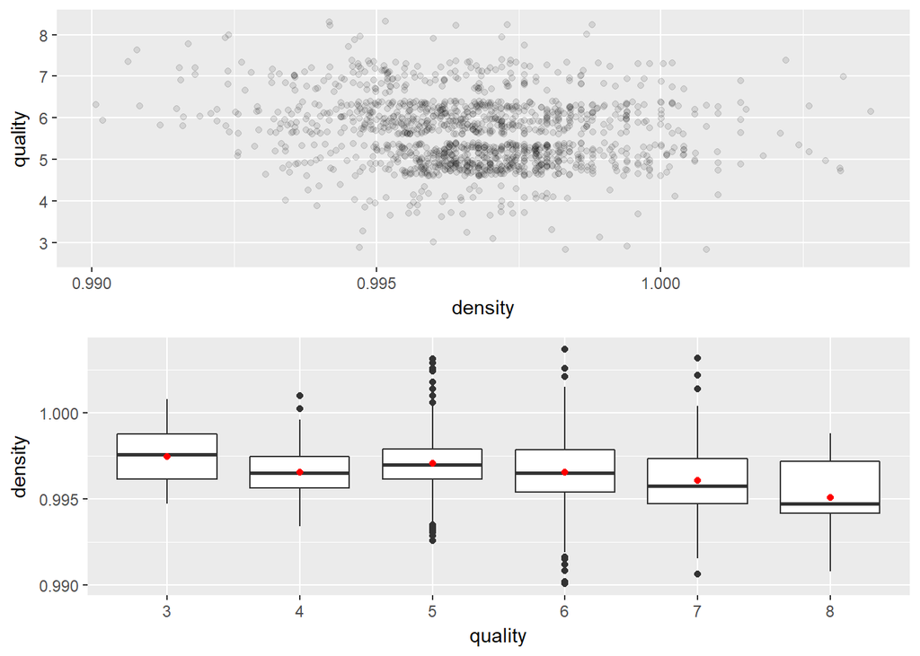

```
## df$quality: 3
##    Min. 1st Qu.  Median    Mean 3rd Qu.    Max.
##  0.9947  0.9961  0.9976  0.9975  0.9988  1.0008
## --------------------------------------------------------
## df$quality: 4
##    Min. 1st Qu.  Median    Mean 3rd Qu.    Max.
##  0.9934  0.9957  0.9965  0.9965  0.9974  1.0010
## --------------------------------------------------------
## df$quality: 5
##    Min. 1st Qu.  Median    Mean 3rd Qu.    Max.
##  0.9926  0.9962  0.9970  0.9971  0.9979  1.0031
## --------------------------------------------------------
## df$quality: 6
##    Min. 1st Qu.  Median    Mean 3rd Qu.    Max.
##  0.9901  0.9954  0.9965  0.9966  0.9979  1.0037
## --------------------------------------------------------
## df$quality: 7
##    Min. 1st Qu.  Median    Mean 3rd Qu.    Max.
##  0.9906  0.9947  0.9958  0.9961  0.9973  1.0032
## --------------------------------------------------------
## df$quality: 8
##    Min. 1st Qu.  Median    Mean 3rd Qu.    Max.
##  0.9908  0.9942  0.9947  0.9951  0.9972  0.9988
```

Quality tends to decrease as density increases.The means and medians of density are decreasing as quality increases overall, even though the difference is slight.

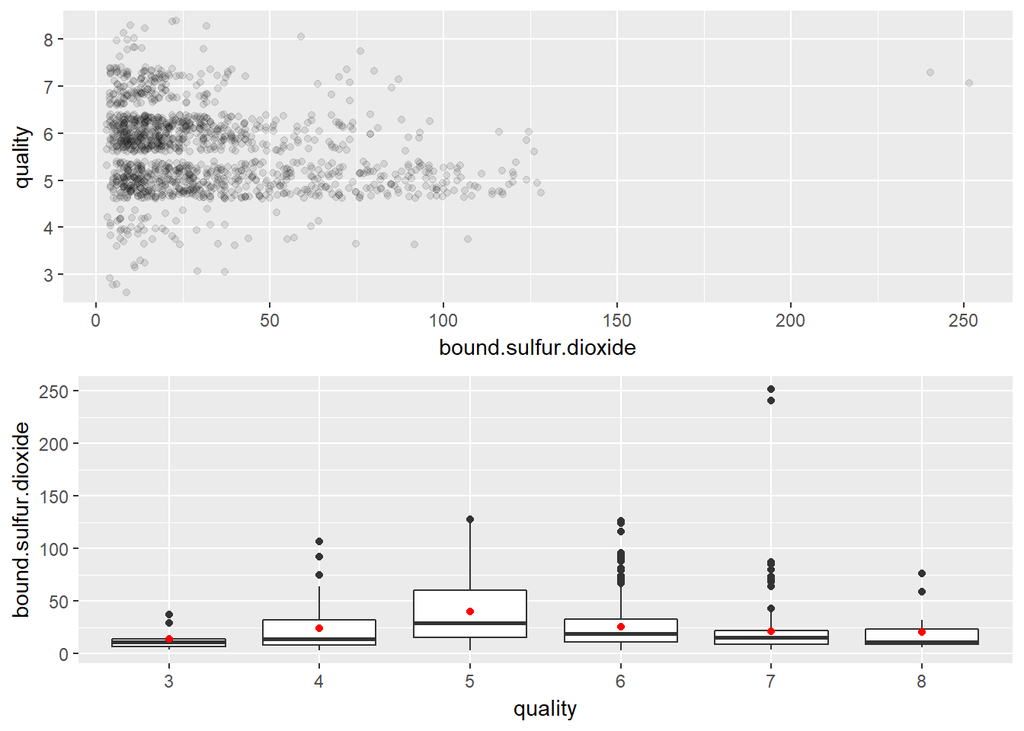

```
## df$quality: 3
##    Min. 1st Qu.  Median    Mean 3rd Qu.    Max.
##    4.00    6.75   11.00   13.90   13.75   37.00
## --------------------------------------------------------
## df$quality: 4
##    Min. 1st Qu.  Median    Mean 3rd Qu.    Max.
##    3.00    8.00   14.00   23.98   32.00  107.00
## --------------------------------------------------------
## df$quality: 5
##    Min. 1st Qu.  Median    Mean 3rd Qu.    Max.
##    3.00   15.00   29.00   40.25   60.00  128.00
## --------------------------------------------------------
## df$quality: 6
##    Min. 1st Qu.  Median    Mean 3rd Qu.    Max.
##    3.00   11.00   19.00   25.18   33.00  126.00
## --------------------------------------------------------
## df$quality: 7
##    Min. 1st Qu.  Median    Mean 3rd Qu.    Max.
##    4.00    8.50   15.00   21.46   21.50  251.50
## --------------------------------------------------------
## df$quality: 8
##    Min. 1st Qu.  Median    Mean 3rd Qu.    Max.
##    6.00    9.00   11.00   20.71   23.00   76.00
```

It looks we only see slight correlation between qualtity and bound.sulfur.dioxide. The meams and medians are increasing then decreasing as quality increases.

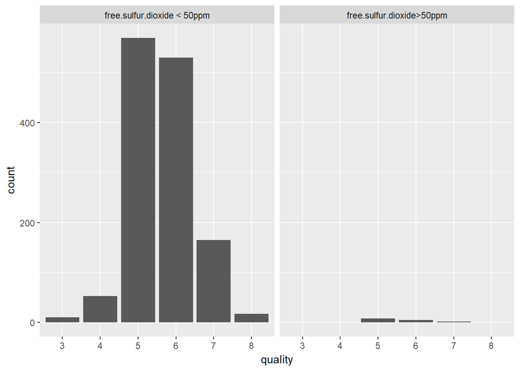

The wines with more than 50 ppm of free.sulfur.dioxide are having not bad quality scores from 5 to 7.

Next, I’ll check how the alcohol varies with some variables that may have meaningful correlations with alcohol. These variables are: volatile.acidity, chlorides, density and PH.

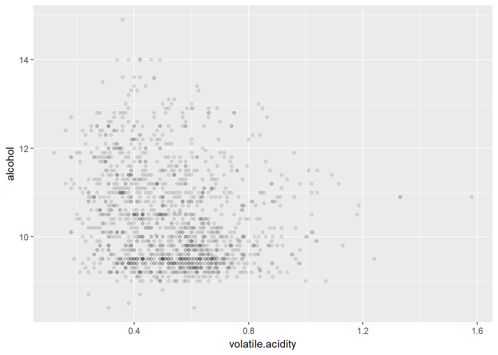

Although both alcohol and volatile.acidity have moderate and almost same correlations with qualtiy, the scatter plot shows the lack of correlations between alcohol and volatile.acidity.

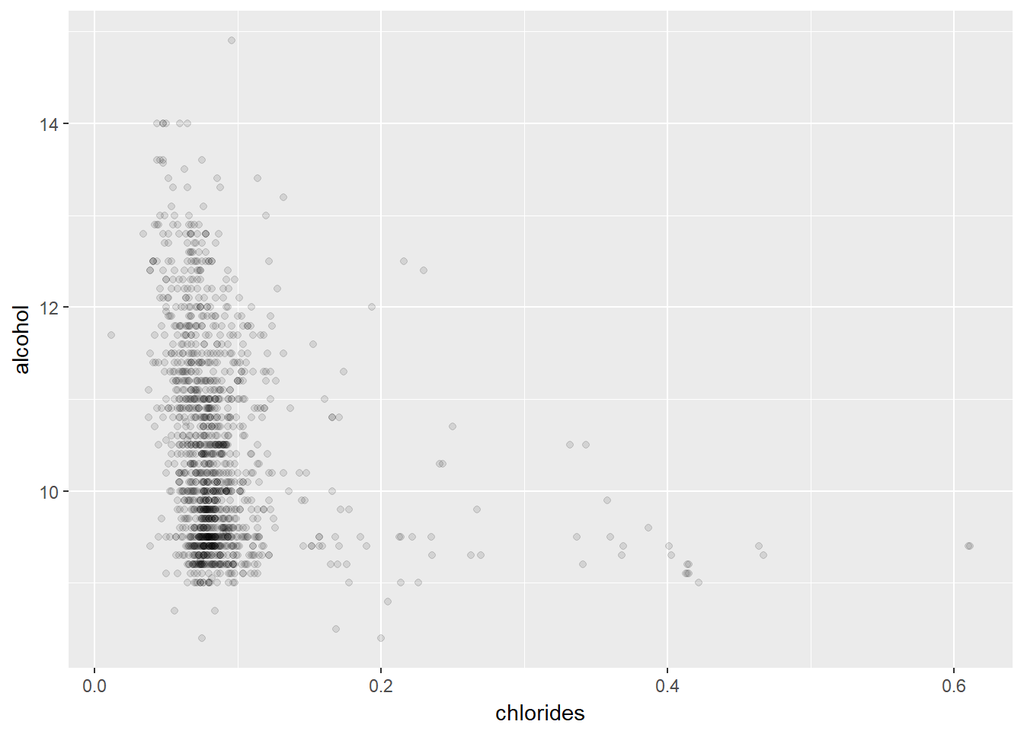

Let’s take a close look at chlorides between 0 to 0.2.

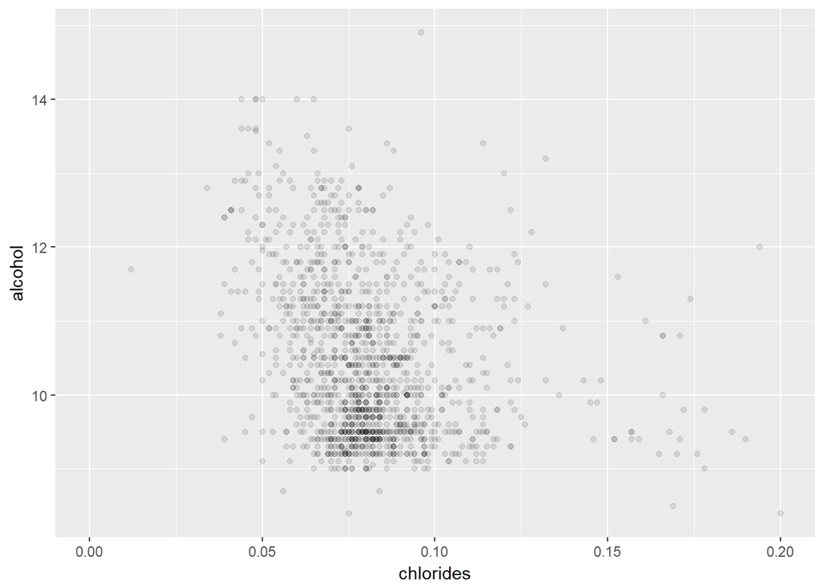

There is slight correlations between chlorides and alcohol. Alcohol is rarely greater than 12 when chlorides are more than 0.125.

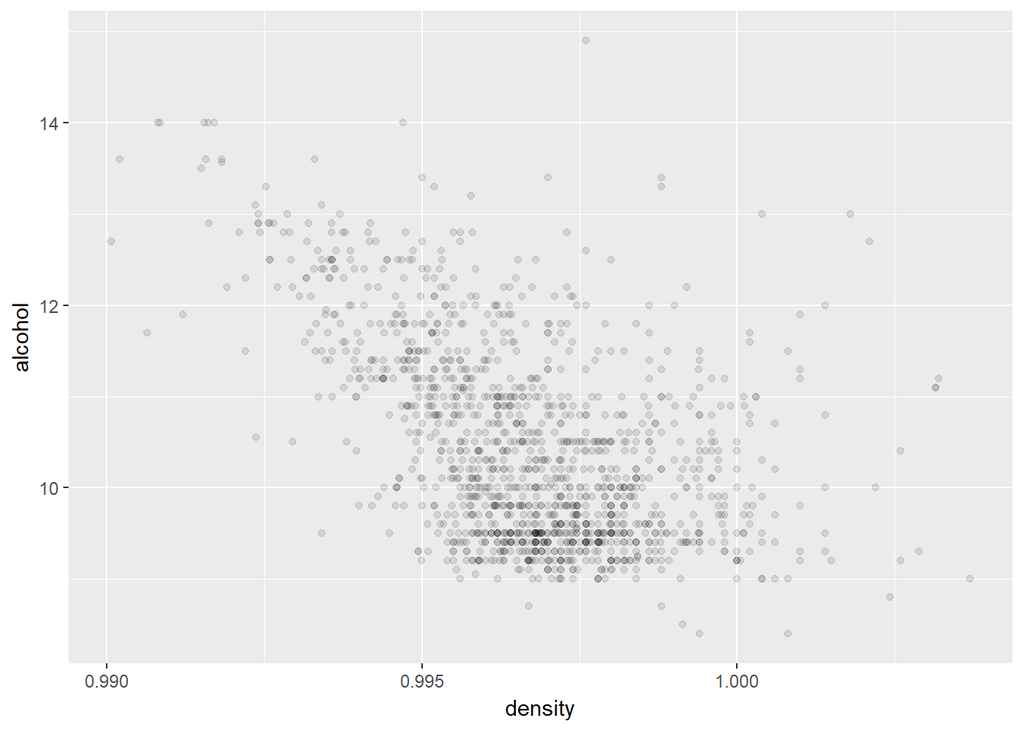

It looks clearly that density and alcohol are negatively correlated.

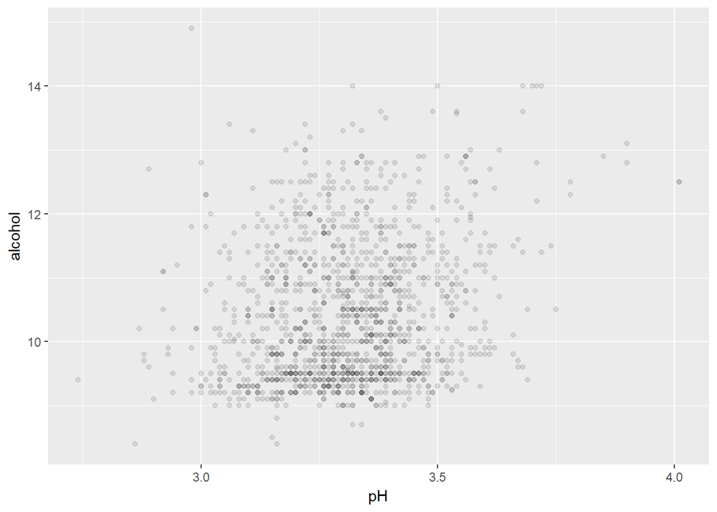

It shows a slight positive correlations between alcohol and pH.

Next, let’s look at the correlation among acidity:fixed.acidity, volatile.acidity, and citric.acid. And I will also check their correlations with pH.

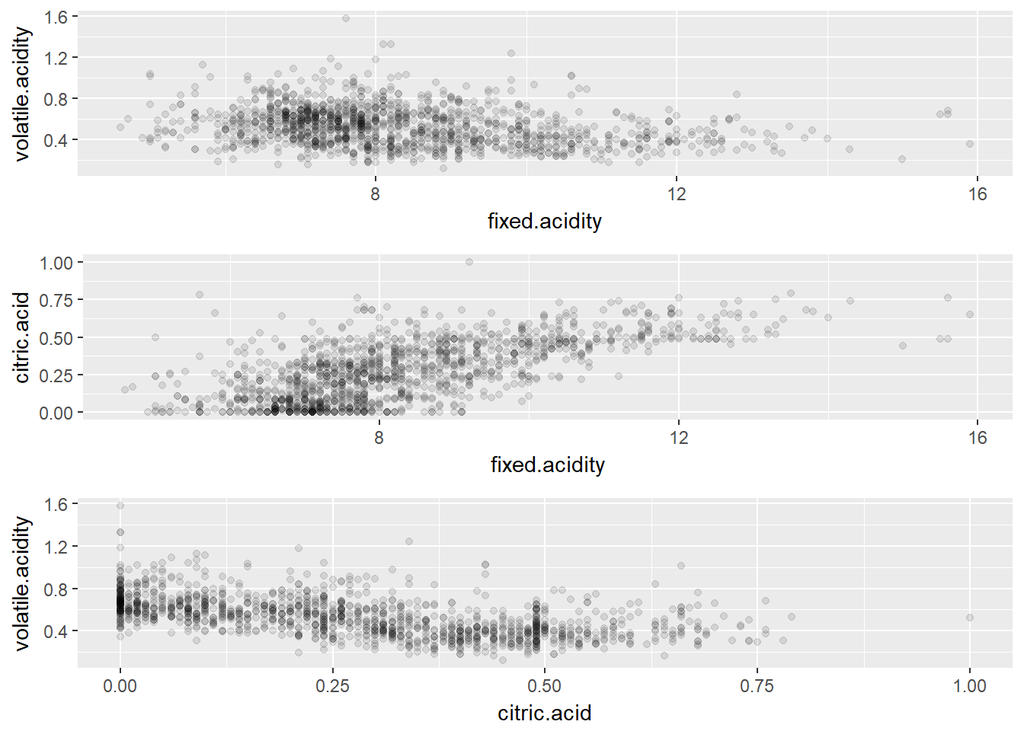

Next, let’s look at their correlations with pH.

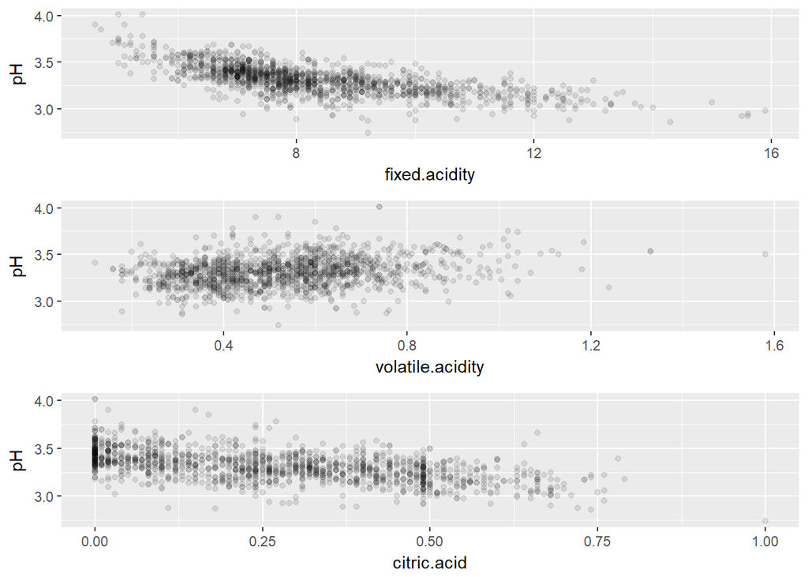

Both citic.acid and fixed.acidity are negatively correlated with pH which makes sense. At the same time, volatile.acidity looks positively correlated with pH, which is also reasonable.